# 데이터 과학 – 기초 통계

교차표 - $\chi^2$ 검정

# 1 코딩기반 범부형 데이터 분석

코딩기반 통계적 추론을 살펴보자. 범주형 데이터의 가장 기본은 **비율(Proportion, $p$)**부터 시작한다. 성별을 얘기할 때, 남성과 여성의 비율이 대표적일 수 있다. 미국의 `GSS(General Socail Survey)`에 견주는 대한민국 [한국복지패널 데이터](https://www.koweps.re.kr:442/main.do)를 얻을 수 있는데, `stata`, `spss`, `sas` 등 상용통계팩키지에 의존성이 있어 이를 R과 같은 오픈소스 소프트웨어에서 작업할 경우 `haven` 팩키지를 동원해야 한다. 그리고 상당량의 변환작업과정과 데이터사전을 보고 일일이 데이터와 대조하는 과정을 거쳐야 한다.

그래서 `forcats` 팩키지에 내장되어 있는 `gss_cat` 범주형 데이터를 가지고 작업을 진행한다.

# 2 교차표 $\chi^2$ 검정 [^1] [^2]

## 2.1 탐색적 데이터 분석

인종(`race`)에 따라 혼인상태(`marital`)가 관계가 있는지 살펴보기 위해서 교차표(crosstabulation), 막대그래프를 그려서 시각적으로 기술통계량으로 확인한다.

```r
# 0. 환경설정 -----
library(infer)
library(tidyverse)
library(cowplot)
library(extrafont)
loadfonts()

# 1. 데이터 -----
## 1.1. 데이터 정제작업 -----
gss_cat_df  <- gss_cat %>%
    filter(year==2014) %>%
    mutate(marital = fct_lump(marital, 1),
           race = fct_lump(race, 1)) %>%
    mutate(marital = fct_recode(marital, Non_Married = "Other"),
           race    = fct_recode(race, Non_White = "Other"))

## 1.2. 교차표 -----
gss_cat_df %>%
    count(marital, race) %>%
    spread(marital, n)
```

```
# A tibble: 2 x 3
  race      Married Non_Married
  <fct>       <int>       <int>
1 White         949         941
2 Non_White     209         439
```

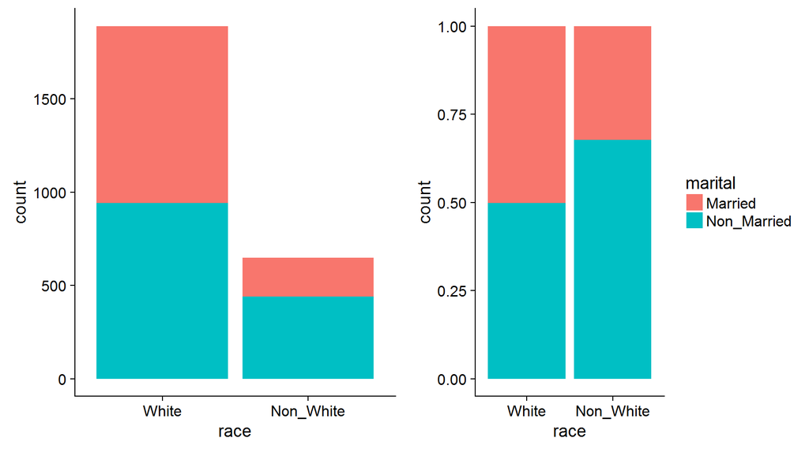

```r
## 1.3. 시각화 -----
marital_orig_g <- gss_cat_df %>%
    ggplot(aes(x=race, fill=marital)) +
      geom_bar() +
      theme(legend.position = "none")

marital_fill_g <- gss_cat_df %>%
    ggplot(aes(x=race, fill=marital)) +
    geom_bar(position = "fill")

plot_grid(marital_orig_g, marital_fill_g)
```

## 2.2 교차표 $\chi^2$ 검정 - 기존 방식

`chisq.test()` 함수를 통해서 혼인상태와 인종간의 차이를 검정할 수 있다. 작성된 `chisq.test()`함수도 오래되었고, 여러사람에 의해 저작되다 보니, 문법에 일관성도 없고 사용법도 제각기다.

- 잘못된 사례
  - `chisq.test(data = car_stop, x = stop_type, y = vehicle_type)`
  - `chisq.test(data = car_stop, formula = vehicle_type ~ stop_type)`

상기 어려움을 극복하고 최종적으로 `데이터프레임$변수명` 다음 문법에 따라 `chisq.test()` 함수를 넣어 돌리면 쉽게 어려움이 극복된다.

더불어 tidyverse 방식에서 널리 쓰이는 `broom` 팩키지를 통계적 추론에 도입하여 `infer` 팩키지에서 제공하는 `chisq_test()` 함수를 사용해도 가능하다.

```r
## 2. 통계검정 -----
### 2.1. Base 함수
chisq.test(gss_cat_df$marital, gss_cat_df$race)
```

```
    Pearson's Chi-squared test with Yates' continuity correction

data:  gss_cat_df$marital and gss_cat_df$race
X-squared = 62.009, df = 1, p-value = 3.418e-15
```

```r
### 2.2. tidyverse 방식
gss_cat_df %>%
    infer::chisq_test(formula = marital ~ race)
```

```
  statistic chisq_df      p_value
1  62.00939        1 3.418227e-15
```

## 2.3 교차표 $\chi^2$ 검정 - 컴퓨팅 방식

컴퓨팅 방식을 사용하면 하나의 프레임워크 내에 이를 담아낼 수 있다. `specify()`에 공식을 입력한다. 범주형 변수 수준이 2개인 경우 `success=`에서 범주 수준을 지정한다. `calculate()`에는 설명변수(`race`)의 수준을 적시한다. 그리고 `visualize()` 함수를 통해서 시각화도 가능하고 `summarize()` 함수로 `p-값`도 산출이 가능하다.

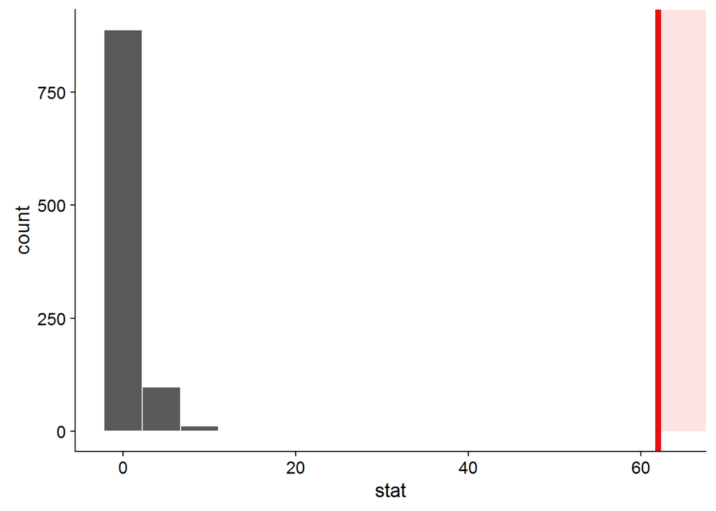

```r
## 3. 코딩기반 통계 검정 -----
### 3.1. 관측점 통계량
obs_chisq <- gss_cat_df %>%
    infer::chisq_test(formula = marital ~ race) %>%
    select(statistic) %>%
    pull()

### 3.2. 귀무가설 통계량
chisq_null <- gss_cat_df %>%
    specify(marital ~ race, success = "Married") %>%
    hypothesize(null = "independence") %>%
    generate(reps = 1000, type = "permute") %>%
    calculate(stat = "Chisq", order=c("White", "Non_White"))

chisq_null %>% visualize(obs_stat = obs_chisq, direction = "greater")
```

```r
### 3.3. p-값 계산
chisq_null %>%
    summarize(p_value = mean(stat >= obs_chisq)) %>%
    pull()
```

```
[1] 0
```

## 2.4 교차표 $\chi^2$ 검정 시각화 - 컴퓨팅 방식

이론으로부터 도출된 귀무가설 통계량 분포를 컴퓨팅 방식으로 산출한 통계량과 겹쳐서 시각화도 가능하다.

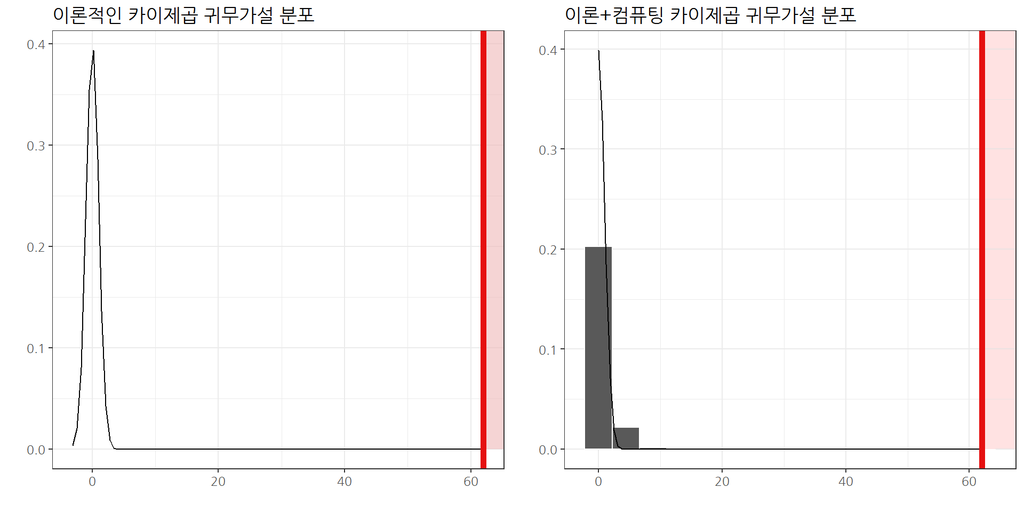

```r
### 3.4. 이론 분포
gss_chisq_g <- gss_cat_df %>%
    specify(marital ~ race, success = "Married") %>%
    hypothesize(null = "independence") %>%
    # generate(reps = 1000, type = "permute") %>%
    calculate(stat = "Chisq", order=c("White", "Non_White")) %>%
    visualize(method = "theoretical", obs_stat = obs_chisq, direction = "right") +
        labs(title="이론적인 카이제곱 귀무가설 분포") +
        theme_bw(base_family = "NanumGothic")

### 3.5. 두 그래프 겹치기
gss_chisq_gg <- gss_cat_df %>%
    specify(marital ~ race, success = "Married") %>%
    hypothesize(null = "independence") %>%
    generate(reps = 1000, type = "permute") %>%
    calculate(stat = "Chisq", order=c("White", "Non_White")) %>%
    visualize(method = "both", obs_stat = obs_chisq, direction = "right") +
        labs(title="이론+컴퓨팅 카이제곱 귀무가설 분포", x="") +
        theme_bw(base_family = "NanumGothic")

plot_grid(gss_chisq_g, gss_chisq_gg, nrow=1)
```

[^1]: [Chi-Squared Test– The Purpose, The Math, When and How to Implement?](https://datascienceplus.com/chi-squared-test-in-r/)
[^2]: [Chester Ismay(2018-05-14), Chi-squared test example using nycflights13 flights data](https://cran.r-project.org/web/packages/infer/vignettes/chisq_test.html)